# Practical Machine Learning - Write-Up Project

Carlos Alberto Guevara Díez

November, 2015

The goal of this project is to use data from accelerometers on the belt, forearm, arm, and dumbell of 6 participants and predict the manner in which people sis the exercise, to be more specific I´m going to predict the classe variable of the data sets, for further information about the description of the project and data used, please refer to the ReadMe file included in this repo.

# Data Pre-Processing and Exploratory Analysis

The first thing to do is to load all the libraries needed to run the functions used in the project.

```r
library(caret)
```

```r
library(ggplot2)
library(corrplot)
library(randomForest)
library (rattle)
```

```
## Versión 3.5.0 Copyright (c) 2006-2015 Togaware Pty Ltd.
## Escriba 'rattle()' para agitar, sacudir y  rotar sus datos.
```

Once loaded I´m going to load the data into R. Note: If you are going to run the code in your own environment please change the first line of the following chunk:

```r
#Adjust this line to your own environment.
setwd("C:/Users/220194/Documents/Data Science Specialization/08 Practical Machine Learning/PracticalMachineLearning")
#Read csv files provided
training <- read.csv("pml-training.csv",na.strings = c("NA", ""))
testing <- read.csv("pml-testing.csv",na.strings = c("NA", ""))
```

At this point I need to make some exploratory analysis on the data in order to identify those columns that do not support the analysis because they are non-numerical. Using what I´ve seen now I’m going to remove columns using the grep function an create a new vector. Note: To make the report easier to read I´m hiding the results of the sapply function, please refer to the appendix section (1) of this report to see the results.

```r
#Explore the class of the columns
sapply(testing,class)
#Using previous exploration generate newe data sets removing non-numerical columns
training_aux <- training[, -(grep("timestamp|X|user_name|num_window|new_window", names(training)))]
testing_aux <- testing[, -(grep("timestamp|X|user_name|num_window|new_window", names(testing)))]
```

As part of the pre-processing tasks I need to get rid of the NA values, as you know The NA`s records make our machine learning algorithm less precise, that´s why is so important to take care of it, once removed I’m updating the vectors I´m going to use in my analysis. Finally I’m going to create my working vectors using a 60%-40% relation between training and testing data sets.

```r
#Identify NAs
NAs <- apply(training_aux, 2, function(x) {
    sum(is.na(x))})
#Remove NAs
training_aux <- training_aux[, which(NAs == 0)]
testing_aux <- testing_aux[, which(NAs == 0)]
#Create Working training and testing data sets.
trainingWS <- training_aux[createDataPartition(y = training_aux$classe, p = 0.6, list = FALSE), ]
testingWS <- training_aux[-createDataPartition(y = training_aux$classe, p = 0.6, list = FALSE), ]
```

Now it´s time to look the changes that I’ve done, once again for more readability of the document I´m hiding the results, please refer to the appendix section (2) of this report to see the results.

```r
#Review the changes in the DataSets
dim(trainingWS)
head(trainingWS)
```

To end with the exploratory tasks I´m showing the following graphic, this one is useful to understand the correlation among the variables, please note the code of color in which the dark blue indicates strong correlation and red negative correlation.

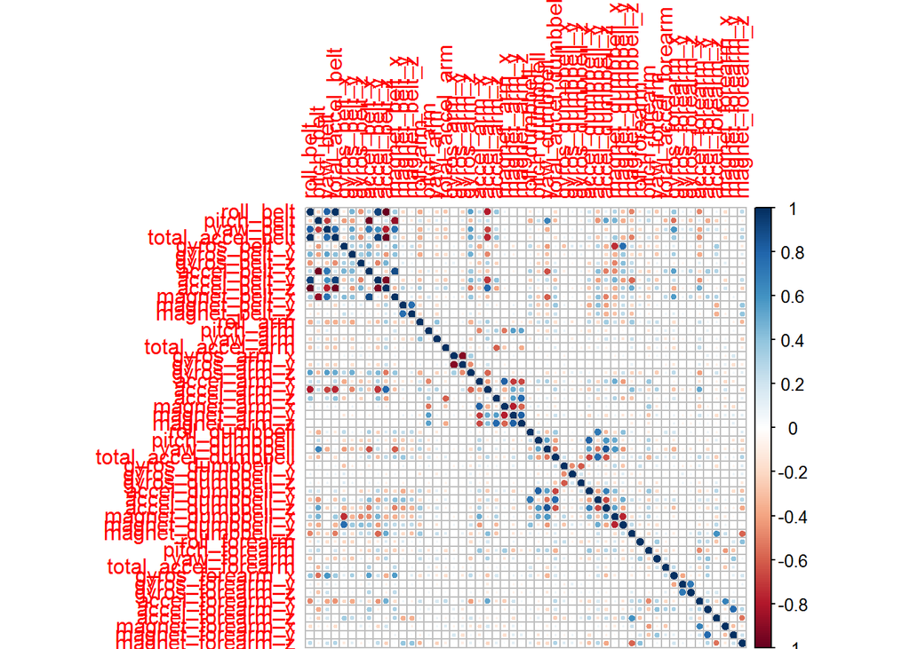

```r
#Remove NAs and then plot a correlation graphic
Graph <- trainingWS
NAs <- apply(trainingWS, 2, function(x) {
    sum(is.na(x))
})
Graph<- trainingWS[, which(NAs == 0)]
CorrePlot = cor( Graph[,-c(grep("timestamp|X|user_name|num_window|new_window",names(Graph)), length(Graph))])
corrplot(CorrePlot, method="circle",tl.cex=1)
```